# Analyzing Housing Features to Find the Best Selling Price

#### A Data Science Project using Predictive Models

#### by Shawn Lee

[Link to GitHub repo](https://github.com/shawng-lee/Pricing-prediction-model)

[Link to original dataset](https://www.kaggle.com/competitions/house-prices-advanced-regression-techniques)

The dataset `train.csv` contains 79 different feature columns describing different aspects of houses sold in Ames, Iowa. The goal is to predict the target variable, `SalePrice` which is the actual selling price of the home. The goal of this prediction is to provide homeowners a reasonable, data-driven benchmark on how they might price their homes before going to market.

```python
import numpy as np
import pandas as pd
import matplotlib.pyplot as plt
import seaborn as sns
from scipy.stats import boxcox
from sklearn.preprocessing import StandardScaler
sns.set(style="white")

df = pd.read_csv('train.csv')

holdout_proportion = 0.1
size_without_holdout = int(len(df)*(1 - holdout_proportion))
df_holdout = df.iloc[size_without_holdout:,:]
df_train = df.iloc[:size_without_holdout,:]

target = df_train['SalePrice']
target_holdout = df_holdout['SalePrice']

features = df_train.iloc[:, 1:-2].copy() # drops id column, target column, and 'SaleCondition' which is unobservable until the sale is actually made
features_holdout = df_holdout.iloc[:,1:-1].copy()
features
```

|  | MSSubClass | MSZoning | LotFrontage | LotArea | Street | Alley | LotShape | LandContour | Utilities | LotConfig | ... | 3SsnPorch | ScreenPorch | PoolArea | PoolQC | Fence | MiscFeature | MiscVal | MoSold | YrSold | SaleType |
| --- | --- | --- | --- | --- | --- | --- | --- | --- | --- | --- | --- | --- | --- | --- | --- | --- | --- | --- | --- | --- | --- |
| 0 | 60 | RL | 65.0 | 8450 | Pave | NaN | Reg | Lvl | AllPub | Inside | ... | 0 | 0 | 0 | NaN | NaN | NaN | 0 | 2 | 2008 | WD |
| 1 | 20 | RL | 80.0 | 9600 | Pave | NaN | Reg | Lvl | AllPub | FR2 | ... | 0 | 0 | 0 | NaN | NaN | NaN | 0 | 5 | 2007 | WD |
| 2 | 60 | RL | 68.0 | 11250 | Pave | NaN | IR1 | Lvl | AllPub | Inside | ... | 0 | 0 | 0 | NaN | NaN | NaN | 0 | 9 | 2008 | WD |
| 3 | 70 | RL | 60.0 | 9550 | Pave | NaN | IR1 | Lvl | AllPub | Corner | ... | 0 | 0 | 0 | NaN | NaN | NaN | 0 | 2 | 2006 | WD |
| 4 | 60 | RL | 84.0 | 14260 | Pave | NaN | IR1 | Lvl | AllPub | FR2 | ... | 0 | 0 | 0 | NaN | NaN | NaN | 0 | 12 | 2008 | WD |
| ... | ... | ... | ... | ... | ... | ... | ... | ... | ... | ... | ... | ... | ... | ... | ... | ... | ... | ... | ... | ... | ... |
| 1309 | 20 | RL | NaN | 7153 | Pave | NaN | Reg | Lvl | AllPub | Inside | ... | 0 | 0 | 0 | NaN | GdWo | NaN | 0 | 6 | 2008 | WD |
| 1310 | 20 | RL | 100.0 | 17500 | Pave | NaN | Reg | Lvl | AllPub | Inside | ... | 0 | 0 | 0 | NaN | NaN | NaN | 0 | 5 | 2010 | WD |
| 1311 | 20 | RL | 68.0 | 8814 | Pave | NaN | Reg | Lvl | AllPub | Inside | ... | 0 | 0 | 0 | NaN | NaN | NaN | 0 | 1 | 2007 | New |
| 1312 | 60 | RL | NaN | 9572 | Pave | NaN | IR1 | Lvl | AllPub | Inside | ... | 0 | 0 | 0 | NaN | NaN | NaN | 0 | 6 | 2007 | WD |
| 1313 | 60 | RL | 108.0 | 14774 | Pave | NaN | IR1 | Lvl | AllPub | Corner | ... | 0 | 0 | 0 | NaN | NaN | NaN | 0 | 5 | 2010 | WD |

1314 rows × 78 columns

- `MSSubClass`: Type of dwelling involved in the sale, indicating style and age. [Categorical]
- `MSZoning`: General zoning classification of the sale. [Categorical, Labels: Agriculture, Commercial, Residential, etc.]
- `LotFrontage`: Linear feet of street connected to the property. [Numeric]
- `LotArea`: Lot size in square feet. [Numeric]
- `Street`: Type of road access to property. [Categorical, Labels: Gravel, Paved]
- `Alley`: Type of alley access to property, if any. [Categorical, Labels: Gravel, Paved, No access]
- `LotShape`: General shape of the property. [Categorical, Labels: Regular, Slightly irregular, etc.]
- `LandContour`: Flatness of the property. [Categorical, Labels: Level, Banked, Hillside, Depression]
- `Utilities`: Types of utilities available. [Categorical, Labels: All public, Electricity and Gas Only, etc.]
- `LotConfig`: Lot configuration. [Categorical, Labels: Inside lot, Corner lot, etc.]
- `LandSlope`: Slope of property. [Categorical, Labels: Gentle slope, Moderate Slope, Severe Slope]
- `Neighborhood`: Physical location within Ames city limits. [Categorical, Labels: Bloomington Heights, Brookside, etc.]
- `Condition1` & `Condition2`: Proximity to various conditions. [Categorical, Labels: Adjacent to arterial street, Normal, etc.]
- `BldgType`: Type of dwelling. [Categorical, Labels: Single-family Detached, Duplex, etc.]
- `HouseStyle`: Style of dwelling. [Categorical, Labels: One story, Two story, etc.]
- `OverallQual`: Overall material and finish of the house. [Ordinal, Scale: 1-10]
- `OverallCond`: Overall condition of the house. [Ordinal, Scale: 1-10]
- `YearBuilt`: Original construction date. [Datetime]
- `YearRemodAdd`: Remodel date. [Datetime]
- `RoofStyle`: Type of roof. [Categorical, Labels: Flat, Gable, Hip, etc.]
- `RoofMatl`: Roof material. [Categorical, Labels: Clay or Tile, Standard Shingle, etc.]
- `Exterior1st` & `Exterior2nd`: Exterior covering on house. [Categorical, Labels: Asbestos Shingles, Brick Face, etc.]
- `MasVnrType`: Masonry veneer type. [Categorical, Labels: Brick Face, None, Stone, etc.]
- `MasVnrArea`: Masonry veneer area in square feet. [Numeric]
- `ExterQual`: Quality of the material on the exterior. [Categorical, Labels: Excellent, Good, Average, etc.]
- `ExterCond`: Present condition of the material on the exterior. [Categorical, Labels: Excellent, Good, Average, etc.]
- `Foundation`: Type of foundation. [Categorical, Labels: Brick & Tile, Poured Concrete, etc.]
- `BsmtQual`: Height of the basement. [Ordinal/Categorical, Labels: Excellent, Good, Typical, etc.]
- `BsmtCond`: General condition of the basement. [Ordinal/Categorical, Labels: Excellent, Good, Typical, etc.]
- `BsmtExposure`: Walkout or garden level basement walls. [Categorical, Labels: Good Exposure, No Exposure, etc.]
- `BsmtFinType1` & `BsmtFinType2`: Rating of basement finished area. [Ordinal/Categorical, Labels: Good Living Quarters, Average, etc.]
- `BsmtFinSF1` & `BsmtFinSF2`: Type 1 and type 2 finished square feet in the basement. [Numeric]
- `BsmtUnfSF`: Unfinished square feet of basement area. [Numeric]
- `TotalBsmtSF`: Total square feet of basement area. [Numeric]
- `Heating`: Type of heating. [Categorical, Labels: Gas forced warm air furnace, Hot water or steam heat, etc.]
- `HeatingQC`: Heating quality and condition. [Categorical, Labels: Excellent, Good, Average, etc.]
- `CentralAir`: Central air conditioning presence. [Binary/Categorical, Labels: Yes, No]
- `Electrical`: Electrical system type. [Categorical, Labels: Standard Circuit Breakers, Fuse Box, etc.]
- `1stFlrSF` & `2ndFlrSF`: First and second floor square feet. [Numeric]
- `LowQualFinSF`: Low quality finished square feet (all floors). [Numeric]
- `GrLivArea`: Above grade living area square feet. [Numeric]
- `BsmtFullBath`: Basement full bathrooms. [Numeric, potentially Categorical for analysis]
- `BsmtHalfBath`: Basement half bathrooms. [Numeric, potentially Categorical for analysis]
- `FullBath`: Full bathrooms above grade. [Numeric, potentially Categorical for analysis]
- `HalfBath`: Half baths above grade. [Numeric, potentially Categorical for analysis]
- `Bedroom`: Bedrooms above grade (excluding basement bedrooms). [Numeric, potentially Categorical for analysis]
- `Kitchen`: Kitchens above grade. [Numeric, potentially Categorical for analysis]
- `KitchenQual`: Kitchen quality. [Categorical, Labels: Excellent, Good, Typical, etc.]
- `TotRmsAbvGrd`: Total rooms above grade (excluding bathrooms). [Numeric]
- `Functional`: Home functionality rating. [Categorical, Labels: Typical, Minor Deductions, Major Deductions, etc.]
- `Fireplaces`: Number of fireplaces. [Numeric]
- `FireplaceQu`: Fireplace quality. [Categorical, Labels: Excellent, Good, Average, etc.]
- `GarageType`: Garage location type. [Categorical, Labels: Attached, Detached, Built-In, etc.]
- `GarageYrBlt`: Year garage was built. [Datetime]
- `GarageFinish`: Interior finish of the garage. [Categorical, Labels: Finished, Rough Finished, Unfinished]
- `GarageCars`: Size of garage in car capacity. [Numeric]
- `GarageArea`: Size of garage in square feet. [Numeric]
- `GarageQual`: Garage quality. [Categorical, Labels: Excellent, Good, Typical, etc.]
- `GarageCond`: Garage condition. [Categorical, Labels: Excellent, Good, Typical, etc.]
- `PavedDrive`: Paved driveway. [Categorical, Labels: Paved, Partial Pavement, Dirt/Gravel]
- `WoodDeckSF`: Wood deck area in square feet. [Numeric]
- `OpenPorchSF`: Open porch area in square feet. [Numeric]
- `EnclosedPorch`: Enclosed porch area in square feet. [Numeric]
- `3SsnPorch`: Three-season porch area in square feet. [Numeric]
- `ScreenPorch`: Screen porch area in square feet. [Numeric]
- `PoolArea`: Pool area in square feet. [Numeric]
- `PoolQC`: Pool quality. [Categorical, Labels: Excellent, Good, Average, etc.]
- `Fence`: Fence quality. [Categorical, Labels: Good Privacy, Minimum Privacy, Good Wood, etc.]
- `MiscFeature`: Miscellaneous feature not covered in other categories. [Categorical, Labels: Elevator, Shed, Tennis Court, etc.]
- `MiscVal`: $Value of miscellaneous feature. [Numeric]
- `MoSold`: Month Sold (MM). [Categorical, could be converted to datetime or string for analysis]
- `YrSold`: Year Sold (YYYY). [Datetime]
- `SaleType`: Type of sale. [Categorical, Labels: Warranty Deed, New, COD, etc.]
- `SaleCondition`: Condition of sale. [Categorical, Labels: Normal, Abnormal, Adjoining Land Purchase, etc.]

# 1. Exploratory Data Analysis

### 1.1 Visualizing the feature distributions

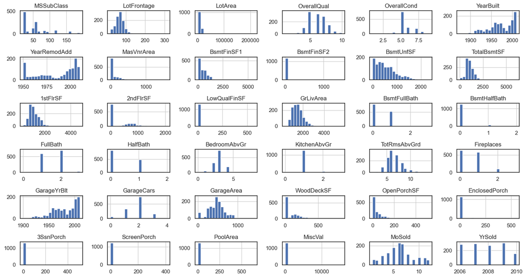

```python
# plot the distributions of all features
features.hist(bins=20, figsize=(15, 8))
plt.tight_layout()
plt.show()
```

Notes:

- Some continuous variables are heavily weighted at 0. A binary variable can be created to indicate zero or non-zero to smooth out the information in the data. This may improve the generalizability of the models. It should be noted that this increases the risk of high multicolinearity, which will be addressed in the predictive models used.
- Some numeric variables are discrete counts of a home feature, such as `FullBath`, `BedroomAbvGr`, `Fireplaces`, etc. These can be converted to categorical variables before training the data. Rating data such as `OverallQual`, `OverallCond` will be treated similarly.
- `YearRemodAdd` is heavily weighted at 1950. This might suggest that missing values were set to 1950 as a default.

### 1.2 Describing the data with some key statistics

```python
def eda_summary(df):
    numeric = features.select_dtypes(include=['float', 'int64']).columns
    return pd.DataFrame({
        'Mean': df[numeric].mean().round(2),
        'Std': df[numeric].std().round(2),
        'Median': df[numeric].median(),
        'Missing Values': df[numeric].isna().sum(),
        'Zero Values': (df[numeric] == 0).sum(),
        'Proportion Zero Values': ((df[numeric] == 0).sum() / len(df)).round(2),
        'Unique Values': df[numeric].nunique()
    })

features_summary = eda_summary(features)
features_summary
```

|  | Mean | Std | Median | Missing Values | Zero Values | Proportion Zero Values | Unique Values |
| --- | --- | --- | --- | --- | --- | --- | --- |
| MSSubClass | 57.01 | 42.46 | 50.0 | 0 | 0 | 0.00 | 15 |
| LotFrontage | 70.28 | 24.64 | 70.0 | 233 | 0 | 0.00 | 108 |
| LotArea | 10566.03 | 10339.71 | 9476.5 | 0 | 0 | 0.00 | 986 |
| OverallQual | 6.11 | 1.38 | 6.0 | 0 | 0 | 0.00 | 10 |
| OverallCond | 5.57 | 1.12 | 5.0 | 0 | 0 | 0.00 | 9 |
| YearBuilt | 1971.48 | 29.91 | 1973.0 | 0 | 0 | 0.00 | 110 |
| YearRemodAdd | 1984.81 | 20.58 | 1993.0 | 0 | 0 | 0.00 | 61 |
| MasVnrArea | 104.89 | 183.63 | 0.0 | 8 | 769 | 0.59 | 305 |
| BsmtFinSF1 | 447.95 | 461.30 | 387.0 | 0 | 415 | 0.32 | 602 |
| BsmtFinSF2 | 45.75 | 159.67 | 0.0 | 0 | 1165 | 0.89 | 129 |
| BsmtUnfSF | 566.69 | 441.48 | 473.5 | 0 | 109 | 0.08 | 734 |
| TotalBsmtSF | 1060.40 | 442.08 | 1001.5 | 0 | 35 | 0.03 | 679 |
| 1stFlrSF | 1162.66 | 386.84 | 1088.0 | 0 | 0 | 0.00 | 717 |
| 2ndFlrSF | 345.76 | 436.81 | 0.0 | 0 | 749 | 0.57 | 384 |
| LowQualFinSF | 5.98 | 49.80 | 0.0 | 0 | 1291 | 0.98 | 22 |
| GrLivArea | 1514.40 | 526.16 | 1456.0 | 0 | 0 | 0.00 | 810 |
| BsmtFullBath | 0.43 | 0.52 | 0.0 | 0 | 772 | 0.59 | 4 |
| BsmtHalfBath | 0.06 | 0.24 | 0.0 | 0 | 1238 | 0.94 | 3 |
| FullBath | 1.56 | 0.55 | 2.0 | 0 | 9 | 0.01 | 4 |
| HalfBath | 0.38 | 0.50 | 0.0 | 0 | 820 | 0.62 | 3 |
| BedroomAbvGr | 2.86 | 0.82 | 3.0 | 0 | 6 | 0.00 | 8 |
| KitchenAbvGr | 1.05 | 0.22 | 1.0 | 0 | 1 | 0.00 | 4 |
| TotRmsAbvGrd | 6.51 | 1.62 | 6.0 | 0 | 0 | 0.00 | 12 |
| Fireplaces | 0.61 | 0.65 | 1.0 | 0 | 624 | 0.47 | 4 |
| GarageYrBlt | 1978.45 | 24.55 | 1980.0 | 72 | 0 | 0.00 | 95 |
| GarageCars | 1.76 | 0.74 | 2.0 | 0 | 72 | 0.05 | 5 |
| GarageArea | 473.26 | 212.76 | 479.5 | 0 | 72 | 0.05 | 418 |
| WoodDeckSF | 95.90 | 125.20 | 0.0 | 0 | 674 | 0.51 | 265 |
| OpenPorchSF | 46.18 | 65.66 | 24.0 | 0 | 600 | 0.46 | 192 |
| EnclosedPorch | 21.45 | 60.56 | 0.0 | 0 | 1130 | 0.86 | 111 |
| 3SsnPorch | 3.34 | 28.68 | 0.0 | 0 | 1292 | 0.98 | 18 |
| ScreenPorch | 14.98 | 54.58 | 0.0 | 0 | 1209 | 0.92 | 68 |
| PoolArea | 2.11 | 34.32 | 0.0 | 0 | 1309 | 1.00 | 6 |
| MiscVal | 44.02 | 514.64 | 0.0 | 0 | 1265 | 0.96 | 19 |
| MoSold | 6.32 | 2.70 | 6.0 | 0 | 0 | 0.00 | 12 |
| YrSold | 2007.81 | 1.33 | 2008.0 | 0 | 0 | 0.00 | 5 |

Notes:

- `LotFrontage` missing values are likely cases where the house does not have any measurable frontage as part of the lot. The same can be said for `MasVnrArea`. These will be converted to 0 for simplicity in the pre-processing stage.
- `GarageYrBlt` missing values are likely cases where the house does not have a garage. This is a bit tricky since setting the year to 0 would not be as meaningful. Instead, the data can be imputed by replacing the mising values wih the median of `GarageYrBlt`. Median is used because the skew in the distribution of data suggests it is a better measure of central tendency.

# 2. Pre-processing

### 2.1 Imputing missing values from the results in section 1.2

```python
# Fill up missing values
features['LotFrontage'] = features['LotFrontage'].fillna(0)
features['MasVnrArea'] = features['MasVnrArea'].fillna(0)
features['GarageYrBlt'] = features['GarageYrBlt'].fillna(np.median(features['GarageYrBlt'])) # Substitute NaN to the mean value since NaN means there is no Garage

# Update the summary table
features_summary = eda_summary(features)
```

```python
# repeat for the holdout set
features_holdout['LotFrontage'] = features_holdout['LotFrontage'].fillna(0)
features_holdout['MasVnrArea'] = features_holdout['MasVnrArea'].fillna(0)
features_holdout['GarageYrBlt'] = features_holdout['GarageYrBlt'].fillna(np.median(features['GarageYrBlt'])) # still use the median of the training set
```

### 2.2 Categorizing features according to notes in section 1.1

```python
# Initialize lists for classification
numeric = features.select_dtypes(include=['float', 'int64']).columns.tolist()
create_binary = []
categorical = []
datetime = []

# Iterate through the summary DataFrame to classify columns
for column in features_summary.index:
    if features_summary.loc[column, 'Proportion Zero Values'] >= 0.5:  # 0.5 is arbitrary; if more than half the values of a feature are 0, a binary variable will be created to represent zero or non-zero
        create_binary.append(column)
    elif features_summary.loc[column, 'Unique Values'] <= 15: # 15 is based on the number of classes in 'MSSubClass'; if a feature has 15 or less classes, it should be considered a categorical variable
        categorical.append(column)
    if 'Year' in column or 'Yr' in column:
        datetime.append(column)

# Adjust lists to avoid duplicate categorizing
categorical = [col for col in categorical if col not in datetime]
continuous = [col for col in numeric if col not in categorical and col not in datetime]

# Print out the classified lists
print("Numeric (Continuous):", continuous)
print("Create Binary:", create_binary)
print("Categorical:", categorical)
print("Datetime:", datetime)
```

```
Numeric (Continuous): ['LotFrontage', 'LotArea', 'MasVnrArea', 'BsmtFinSF1', 'BsmtFinSF2', 'BsmtUnfSF', 'TotalBsmtSF', '1stFlrSF', '2ndFlrSF', 'LowQualFinSF', 'GrLivArea', 'BsmtFullBath', 'BsmtHalfBath', 'HalfBath', 'GarageArea', 'WoodDeckSF', 'OpenPorchSF', 'EnclosedPorch', '3SsnPorch', 'ScreenPorc…
Create Binary: ['MasVnrArea', 'BsmtFinSF2', '2ndFlrSF', 'LowQualFinSF', 'BsmtFullBath', 'BsmtHalfBath', 'HalfBath', 'WoodDeckSF', 'EnclosedPorch', '3SsnPorch', 'ScreenPorch', 'PoolArea', 'MiscVal']
Categorical: ['MSSubClass', 'OverallQual', 'OverallCond', 'FullBath', 'BedroomAbvGr', 'KitchenAbvGr', 'TotRmsAbvGrd', 'Fireplaces', 'GarageCars', 'MoSold']
Datetime: ['YearBuilt', 'YearRemodAdd', 'GarageYrBlt', 'YrSold']
```

### 2.3 Converting variables to binary

```python
# Transform features that are better estimated as binary columns into binary
for column in create_binary[:]:  # Iterate over a slice copy of the list
    features[f'{column}_binary'] = features[column].apply(lambda x: 'Zero' if x == 0 else 'Non-Zero')
```

```python
# repeat for the holdout set
for column in create_binary[:]:
    features_holdout[f'{column}_binary'] = features_holdout[column].apply(lambda x: 'Zero' if x == 0 else 'Non-Zero')
```

### 2.4 Creating dummy variables for categorical features

```python
for column in categorical:
    features[column] = features[column].astype(str)

features = pd.get_dummies(features, drop_first=True, dtype='int64')
```

```python
for column in categorical:
    features_holdout[column] = features_holdout[column].astype(str)

features_holdout = pd.get_dummies(features_holdout, drop_first=True, dtype='int64')
```

```python
# Align features_holdout to features
features, features_holdout = features.align(features_holdout, join='left', axis=1, fill_value=0)
```

### 2.5 Adjusting skewness on remaining continuous variables

Some predictive models may perform better when the data is not skewed. Reducing skewness can be done through Box-Cox transformations. It should be considered that such transformations should only be applied to meaningfully skewed data (skew > 1).

```python
# observe the skew of all continuous variables
skewness = features[continuous].skew()
print(skewness)
```

```
LotFrontage       0.317149
LotArea          12.116420
MasVnrArea        2.720332
BsmtFinSF1        1.751786
BsmtFinSF2        4.313743
BsmtUnfSF         0.928088
TotalBsmtSF       1.588691
1stFlrSF          1.425646
2ndFlrSF          0.822391
LowQualFinSF      8.927897
GrLivArea         1.456689
BsmtFullBath      0.623402
BsmtHalfBath      4.049921
HalfBath          0.659845
GarageArea        0.202448
WoodDeckSF        1.482956
OpenPorchSF       2.261692
EnclosedPorch     3.175057
3SsnPorch        10.603192
ScreenPorch       3.903798
PoolArea         16.402609
MiscVal          24.234827
dtype: float64
```

```
LotArea           0.019960
MasVnrArea        0.412756
BsmtFinSF1       -0.414541
BsmtFinSF2        2.441375
TotalBsmtSF       0.239796
1stFlrSF         -0.001323
LowQualFinSF      7.366962
GrLivArea        -0.000822
BsmtHalfBath      3.792584
WoodDeckSF        0.102627
OpenPorchSF       0.001492
EnclosedPorch     2.077028
3SsnPorch         7.541493
ScreenPorch       3.102112
PoolArea         16.136858
MiscVal           4.889748
dtype: float64
```

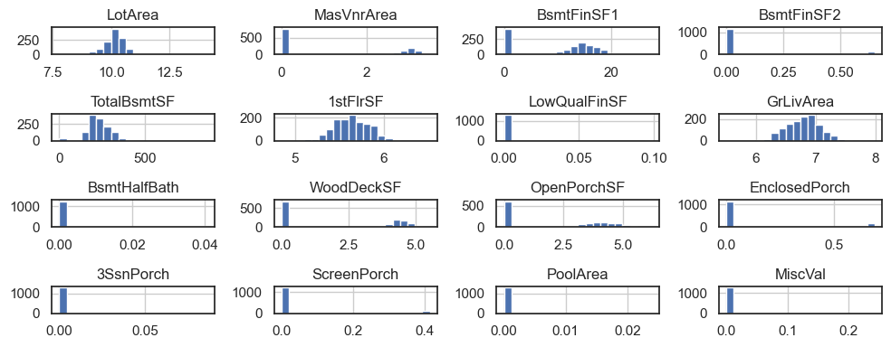

```python
# Apply Box-Cox transformations on data with skew > 1
excluded_columns = []
successful_transforms = []

for column in continuous:
    try:
        if abs(skewness[column]) > 1:
            min_value = features[column].min()            # Adjust data by adding a constant if any values are non-positive
            shift = 0
            if min_value <= 0:
                shift = abs(min_value) + 1
            features[column], fitted_lambda = boxcox(features[column] + shift)
            successful_transforms.append(column)
    except Exception as e:
        print(f"Skipping {column} due to error: {e}")
        excluded_columns.append(column)

# Display the new skewness values for the transformed columns
new_skewness = features[successful_transforms].skew()
print(new_skewness)

# Plot the distributions of the transformed columns
features[successful_transforms].hist(bins=20, figsize=(10, 4))
plt.tight_layout()
plt.show()
```

```
LotArea          0.065100
MasVnrArea       0.561333
BsmtFinSF1      -0.380633
BsmtFinSF2       2.315527
TotalBsmtSF      0.122736
1stFlrSF         0.010843
LowQualFinSF     6.829632
GrLivArea       -0.021541
BsmtHalfBath     4.671572
WoodDeckSF       0.418658
OpenPorchSF     -0.129047
EnclosedPorch    1.830062
3SsnPorch        8.454541
ScreenPorch      3.251295
PoolArea         8.454541
MiscVal          6.829632
dtype: float64
```

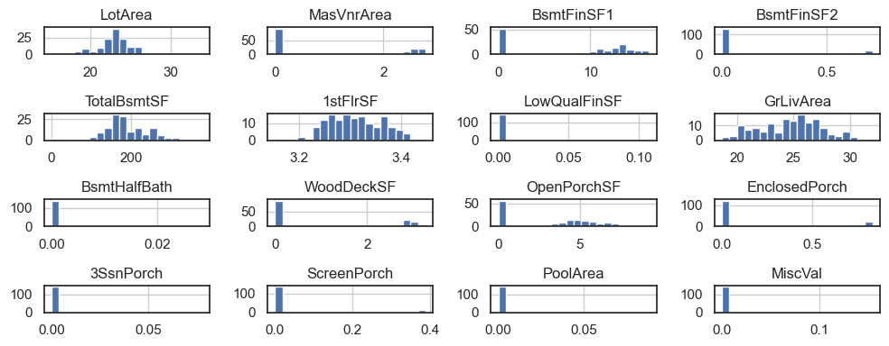

```python
# repeat for the holdout set
excluded_columns_holdout = []
successful_transforms_holdout = []

# use the original successful_transforms from the training data
for column in successful_transforms:
    try:
        min_value_holdout = features_holdout[column].min()
        shift_holdout = 0
        if min_value_holdout <= 0:
            shift_holdout = abs(min_value_holdout) + 1
        features_holdout[column], fitted_lambda = boxcox(features_holdout[column] + shift_holdout)
        successful_transforms_holdout.append(column)
    except Exception as e:
        print(f"Skipping {column} due to error: {e}")
        excluded_columns_holdout.append(column)

new_skewness_holdout = features_holdout[successful_transforms_holdout].skew()
print(new_skewness_holdout)
features_holdout[successful_transforms_holdout].hist(bins=20, figsize=(10, 4))
plt.tight_layout()
plt.show()
```

### 2.6 Scaling the continuous variables

```python
scaler = StandardScaler()

features_scaled = features.copy()
features_scaled[continuous] = scaler.fit_transform(features_scaled[continuous])
features_scaled
```

|  | LotFrontage | LotArea | YearBuilt | YearRemodAdd | MasVnrArea | BsmtFinSF1 | BsmtFinSF2 | BsmtUnfSF | TotalBsmtSF | 1stFlrSF | ... | LowQualFinSF_binary_Zero | BsmtFullBath_binary_Zero | BsmtHalfBath_binary_Zero | HalfBath_binary_Zero | WoodDeckSF_binary_Zero | EnclosedPorch_binary_Zero | 3SsnPorch_binary_Zero | ScreenPorch_binary_Zero | PoolArea_binary_Zero | MiscVal_binary_Zero |
| --- | --- | --- | --- | --- | --- | --- | --- | --- | --- | --- | --- | --- | --- | --- | --- | --- | --- | --- | --- | --- | --- |
| 0 | 0.205667 | -0.142949 | 2003 | 2003 | 1.222277 | 0.790479 | -0.357627 | -0.944206 | -0.406873 | -0.800318 | ... | 1 | 0 | 1 | 0 | 1 | 1 | 1 | 1 | 1 | 1 |
| 1 | 0.635174 | 0.103493 | 1976 | 1976 | -0.824552 | 1.006237 | -0.357627 | -0.640565 | 0.498492 | 0.426942 | ... | 1 | 1 | 0 | 1 | 0 | 1 | 1 | 1 | 1 | 1 |
| 2 | 0.291568 | 0.410798 | 2001 | 2002 | 1.184635 | 0.562589 | -0.357627 | -0.300668 | -0.257794 | -0.570037 | ... | 1 | 0 | 1 | 0 | 1 | 1 | 1 | 1 | 1 | 1 |
| 3 | 0.062498 | 0.093394 | 1915 | 1970 | -0.824552 | 0.131148 | -0.357627 | -0.060474 | -0.645755 | -0.431304 | ... | 1 | 0 | 1 | 1 | 1 | 0 | 1 | 1 | 1 | 1 |
| 4 | 0.749709 | 0.872190 | 2000 | 2000 | 1.327142 | 0.743113 | -0.357627 | -0.173773 | 0.246556 | 0.122215 | ... | 1 | 0 | 1 | 0 | 0 | 1 | 1 | 1 | 1 | 1 |
| ... | ... | ... | ... | ... | ... | ... | ... | ... | ... | ... | ... | ... | ... | ... | ... | ... | ... | ... | ... | ... | ... |
| 1309 | -1.655531 | -0.463742 | 1991 | 1991 | 1.052436 | 1.150273 | -0.357627 | -1.107357 | 0.532464 | 0.505062 | ... | 1 | 0 | 1 | 1 | 0 | 1 | 1 | 1 | 1 | 1 |
| 1310 | 1.207850 | 1.272585 | 1959 | 2002 | -0.824552 | 1.266625 | -0.357627 | -0.160178 | 1.785174 | 1.690974 | ... | 1 | 0 | 1 | 1 | 1 | 0 | 1 | 1 | 1 | 1 |
| 1311 | 0.291568 | -0.061569 | 2005 | 2007 | 1.030101 | 0.968181 | -0.357627 | -0.493277 | 0.523981 | 0.456481 | ... | 1 | 0 | 1 | 1 | 0 | 1 | 1 | 1 | 1 | 1 |
| 1312 | -1.655531 | 0.097844 | 1990 | 1990 | 1.320213 | 0.557766 | -0.357627 | 0.916163 | 0.897209 | 0.864982 | ... | 1 | 1 | 1 | 0 | 0 | 1 | 1 | 1 | 1 | 1 |
| 1313 | 1.436920 | 0.941309 | 1999 | 1999 | 1.188332 | -1.360464 | -0.357627 | 1.872406 | 0.773506 | 0.798209 | ... | 1 | 1 | 1 | 0 | 0 | 1 | 1 | 1 | 1 | 1 |

1314 rows × 311 columns

```python
features_scaled_holdout = features_holdout.copy()
features_scaled_holdout[continuous] = scaler.fit_transform(features_scaled_holdout[continuous])
features_scaled_holdout
```

|  | LotFrontage | LotArea | YearBuilt | YearRemodAdd | MasVnrArea | BsmtFinSF1 | BsmtFinSF2 | BsmtUnfSF | TotalBsmtSF | 1stFlrSF | ... | LowQualFinSF_binary_Zero | BsmtFullBath_binary_Zero | BsmtHalfBath_binary_Zero | HalfBath_binary_Zero | WoodDeckSF_binary_Zero | EnclosedPorch_binary_Zero | 3SsnPorch_binary_Zero | ScreenPorch_binary_Zero | PoolArea_binary_Zero | MiscVal_binary_Zero |
| --- | --- | --- | --- | --- | --- | --- | --- | --- | --- | --- | --- | --- | --- | --- | --- | --- | --- | --- | --- | --- | --- |
| 1314 | 0.128633 | -0.203720 | 1954 | 1954 | -0.763940 | 0.880995 | -0.375000 | -0.799908 | -0.142853 | -0.452939 | ... | 1 | 0 | 1 | 1 | 1 | 1 | 1 | 1 | 1 | 1 |
| 1315 | 0.908549 | 0.399894 | 1969 | 1969 | -0.763940 | 0.664513 | 2.667140 | -0.889732 | -0.132890 | 0.003809 | ... | 1 | 1 | 1 | 0 | 0 | 1 | 1 | 1 | 1 | 1 |
| 1316 | 0.159829 | 0.237194 | 2008 | 2008 | 1.357340 | -1.287821 | -0.375000 | 2.357397 | 1.402194 | 1.213540 | ... | 1 | 0 | 1 | 1 | 0 | 1 | 1 | 1 | 1 | 1 |
| 1317 | -0.276924 | -1.417209 | 2006 | 2007 | -0.763940 | -1.287821 | -0.375000 | 1.751086 | 0.811123 | 0.663823 | ... | 1 | 1 | 1 | 1 | 1 | 1 | 1 | 1 | 1 | 1 |
| 1318 | -1.743166 | 1.008440 | 2001 | 2002 | 1.296160 | -1.287821 | -0.375000 | 2.651570 | 1.678559 | 1.474617 | ... | 1 | 1 | 1 | 1 | 0 | 1 | 1 | 1 | 1 | 1 |
| ... | ... | ... | ... | ... | ... | ... | ... | ... | ... | ... | ... | ... | ... | ... | ... | ... | ... | ... | ... | ... | ... |
| 1455 | 0.191026 | -0.269524 | 1999 | 2000 | -0.763940 | -1.287821 | -0.375000 | 0.855094 | -0.130402 | -0.435659 | ... | 1 | 1 | 1 | 0 | 1 | 1 | 1 | 1 | 1 | 1 |
| 1456 | 0.908549 | 0.762190 | 1978 | 1988 | 1.229099 | 0.926323 | 2.665812 | 0.037698 | 1.230250 | 1.883675 | ... | 1 | 0 | 1 | 1 | 0 | 1 | 1 | 1 | 1 | 1 |
| 1457 | 0.315813 | -0.009333 | 1941 | 2006 | -0.763940 | 0.356671 | -0.375000 | 0.684429 | 0.351025 | 0.268406 | ... | 1 | 1 | 1 | 1 | 1 | 1 | 1 | 1 | 1 | 0 |
| 1458 | 0.378206 | 0.134250 | 1950 | 1996 | -0.763940 | -0.347513 | 2.668180 | -1.284956 | 0.175048 | -0.037203 | ... | 1 | 0 | 1 | 1 | 0 | 0 | 1 | 1 | 1 | 1 |
| 1459 | 0.596583 | 0.179276 | 1965 | 1965 | -0.763940 | 0.956055 | 2.667222 | -0.979556 | 0.592927 | 0.440170 | ... | 1 | 0 | 1 | 0 | 0 | 1 | 1 | 1 | 1 | 1 |

146 rows × 311 columns

## 3. Feature engineering

### 3.1 Looking for high correlations in features

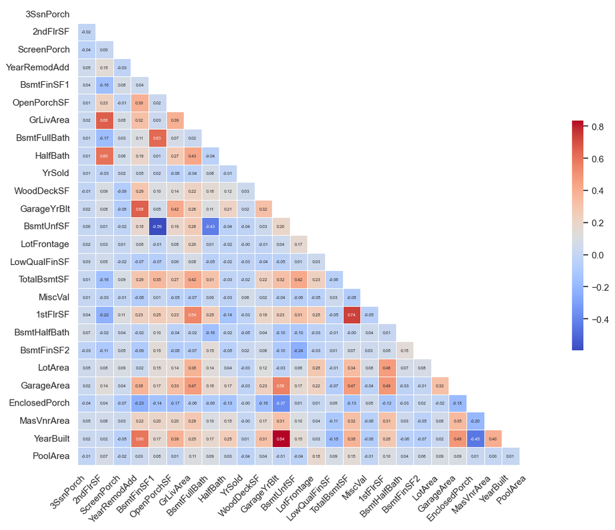

```python
# Looking for highly correlated features
corr_columns = list(set(continuous + datetime))
corr_mat = features_scaled[corr_columns].corr()

plt.figure(figsize=(15, 10))
plt.tight_layout()
mask = np.triu(np.ones_like(corr_mat, dtype=bool))
sns.heatmap(corr_mat, mask=mask, cmap='coolwarm', annot=True, fmt=".2f", annot_kws={'size': 5}, square=True, linewidths=.5, cbar_kws={"shrink": .5})
plt.xticks(rotation=45, ha='right')
plt.show()
```

It should be noted that when picking which variable to remove from a high-correlation pair, the choice of which variable has a salient effect on the information loss. To minimize this, both variables in the high-correlation pair should have its average correlation with all other variables evaluated. The variable with the higher average correlation with all other variables is the one that will be removed. The function below returns a list of removed varaibles until no pair exceeds the correlation threshold specified.

```python
def remove_predictors(data, threshold):
    data_reduced=data.copy()
    predictors_to_remove = []
    while True:
        # Calculate the correlation matrix of the predictors
        corr_mat = data_reduced.corr()
        # Get the absolute pairwise correlations
        corr_mat = np.abs(corr_mat)
        np.fill_diagonal(corr_mat.values, 0)
        corr_mat=corr_mat.fillna(0)

        if corr_mat.max().max()<threshold:
            break

        # Determine the two predictors associated with the largest absolute pairwise correlation
        max_corr = np.unravel_index(np.argmax(corr_mat), corr_mat.shape)
        predictor_A = max_corr[0]
        predictor_B = max_corr[1]

        # Determine the average absolute correlation between A and the other variables
        avg_corr_A = np.mean(corr_mat.iloc[predictor_A, :])
        avg_corr_B = np.mean(corr_mat.iloc[predictor_B, :])

        # If A has a larger average correlation, remove it; otherwise, remove predictor B
        if avg_corr_A > avg_corr_B:
            remove_predictor = predictor_A
            retained_predictor = predictor_B
            predictors_to_remove.append(data_reduced.columns.tolist()[remove_predictor])
        else:
            remove_predictor = predictor_B
            retained_predictor = predictor_A
            predictors_to_remove.append(data_reduced.columns.tolist()[remove_predictor])

        # Remove the predictor
        print(f'Remove: {data_reduced.columns.tolist()[remove_predictor]} and Retain: {data_reduced.columns.tolist()[retained_predictor]}')

        del data_reduced[data_reduced.columns.tolist()[remove_predictor]]

    return predictors_to_remove

columns_to_remove = remove_predictors(features_scaled[corr_columns], 0.7)
```

```
Remove: YearBuilt and Retain: GarageYrBlt
Remove: TotalBsmtSF and Retain: 1stFlrSF
```

- Naturally, the `YearBuilt` and the `GarageYrBlt` would be similar if not equal for most of the time. However, there should be less confidence placed on `GarageYrBlt` because a portion of the data contains naively imputed values from section 2.1. As a result, `GarageYrBlt` will be the column to remove, instead of `YearBuilt`.
- `TotalBsmtSF` is likely related to the `1stFlrSF` as this generally tells us the footprint of the house. That `2ndFlrSF` is not as highly correlated might suggest that basements are more common than second floors.

```python
columns_to_remove = ['GarageYrBlt', 'TotalBsmtSF']
features_scaled = features_scaled.drop(columns=columns_to_remove)
features_scaled
```

|  | LotFrontage | LotArea | YearBuilt | YearRemodAdd | MasVnrArea | BsmtFinSF1 | BsmtFinSF2 | BsmtUnfSF | 1stFlrSF | 2ndFlrSF | ... | LowQualFinSF_binary_Zero | BsmtFullBath_binary_Zero | BsmtHalfBath_binary_Zero | HalfBath_binary_Zero | WoodDeckSF_binary_Zero | EnclosedPorch_binary_Zero | 3SsnPorch_binary_Zero | ScreenPorch_binary_Zero | PoolArea_binary_Zero | MiscVal_binary_Zero |
| --- | --- | --- | --- | --- | --- | --- | --- | --- | --- | --- | --- | --- | --- | --- | --- | --- | --- | --- | --- | --- | --- |
| 0 | 0.205667 | -0.142949 | 2003 | 2003 | 1.222277 | 0.790479 | -0.357627 | -0.944206 | -0.800318 | 1.163954 | ... | 1 | 0 | 1 | 0 | 1 | 1 | 1 | 1 | 1 | 1 |
| 1 | 0.635174 | 0.103493 | 1976 | 1976 | -0.824552 | 1.006237 | -0.357627 | -0.640565 | 0.426942 | -0.791852 | ... | 1 | 1 | 0 | 1 | 0 | 1 | 1 | 1 | 1 | 1 |
| 2 | 0.291568 | 0.410798 | 2001 | 2002 | 1.184635 | 0.562589 | -0.357627 | -0.300668 | -0.570037 | 1.191436 | ... | 1 | 0 | 1 | 0 | 1 | 1 | 1 | 1 | 1 | 1 |
| 3 | 0.062498 | 0.093394 | 1915 | 1970 | -0.824552 | 0.131148 | -0.357627 | -0.060474 | -0.431304 | 0.939517 | ... | 1 | 0 | 1 | 1 | 1 | 0 | 1 | 1 | 1 | 1 |
| 4 | 0.749709 | 0.872190 | 2000 | 2000 | 1.327142 | 0.743113 | -0.357627 | -0.173773 | 0.122215 | 1.619698 | ... | 1 | 0 | 1 | 0 | 0 | 1 | 1 | 1 | 1 | 1 |
| ... | ... | ... | ... | ... | ... | ... | ... | ... | ... | ... | ... | ... | ... | ... | ... | ... | ... | ... | ... | ... | ... |
| 1309 | -1.655531 | -0.463742 | 1991 | 1991 | 1.052436 | 1.150273 | -0.357627 | -1.107357 | 0.505062 | -0.791852 | ... | 1 | 0 | 1 | 1 | 0 | 1 | 1 | 1 | 1 | 1 |
| 1310 | 1.207850 | 1.272585 | 1959 | 2002 | -0.824552 | 1.266625 | -0.357627 | -0.160178 | 1.690974 | -0.791852 | ... | 1 | 0 | 1 | 1 | 1 | 0 | 1 | 1 | 1 | 1 |
| 1311 | 0.291568 | -0.061569 | 2005 | 2007 | 1.030101 | 0.968181 | -0.357627 | -0.493277 | 0.456481 | -0.791852 | ... | 1 | 0 | 1 | 1 | 0 | 1 | 1 | 1 | 1 | 1 |
| 1312 | -1.655531 | 0.097844 | 1990 | 1990 | 1.320213 | 0.557766 | -0.357627 | 0.916163 | 0.864982 | 2.315910 | ... | 1 | 1 | 1 | 0 | 0 | 1 | 1 | 1 | 1 | 1 |
| 1313 | 1.436920 | 0.941309 | 1999 | 1999 | 1.188332 | -1.360464 | -0.357627 | 1.872406 | 0.798209 | 1.903680 | ... | 1 | 1 | 1 | 0 | 0 | 1 | 1 | 1 | 1 | 1 |

1314 rows × 309 columns

```python
features_scaled_holdout = features_scaled_holdout.drop(columns=columns_to_remove)
features_scaled_holdout
```

|  | LotFrontage | LotArea | YearBuilt | YearRemodAdd | MasVnrArea | BsmtFinSF1 | BsmtFinSF2 | BsmtUnfSF | 1stFlrSF | 2ndFlrSF | ... | LowQualFinSF_binary_Zero | BsmtFullBath_binary_Zero | BsmtHalfBath_binary_Zero | HalfBath_binary_Zero | WoodDeckSF_binary_Zero | EnclosedPorch_binary_Zero | 3SsnPorch_binary_Zero | ScreenPorch_binary_Zero | PoolArea_binary_Zero | MiscVal_binary_Zero |
| --- | --- | --- | --- | --- | --- | --- | --- | --- | --- | --- | --- | --- | --- | --- | --- | --- | --- | --- | --- | --- | --- |
| 1314 | 0.128633 | -0.203720 | 1954 | 1954 | -0.763940 | 0.880995 | -0.375000 | -0.799908 | -0.452939 | -0.825463 | ... | 1 | 0 | 1 | 1 | 1 | 1 | 1 | 1 | 1 | 1 |
| 1315 | 0.908549 | 0.399894 | 1969 | 1969 | -0.763940 | 0.664513 | 2.667140 | -0.889732 | 0.003809 | 1.525920 | ... | 1 | 1 | 1 | 0 | 0 | 1 | 1 | 1 | 1 | 1 |
| 1316 | 0.159829 | 0.237194 | 2008 | 2008 | 1.357340 | -1.287821 | -0.375000 | 2.357397 | 1.213540 | -0.825463 | ... | 1 | 0 | 1 | 1 | 0 | 1 | 1 | 1 | 1 | 1 |
| 1317 | -0.276924 | -1.417209 | 2006 | 2007 | -0.763940 | -1.287821 | -0.375000 | 1.751086 | 0.663823 | -0.825463 | ... | 1 | 1 | 1 | 1 | 1 | 1 | 1 | 1 | 1 | 1 |
| 1318 | -1.743166 | 1.008440 | 2001 | 2002 | 1.296160 | -1.287821 | -0.375000 | 2.651570 | 1.474617 | -0.825463 | ... | 1 | 1 | 1 | 1 | 0 | 1 | 1 | 1 | 1 | 1 |
| ... | ... | ... | ... | ... | ... | ... | ... | ... | ... | ... | ... | ... | ... | ... | ... | ... | ... | ... | ... | ... | ... |
| 1455 | 0.191026 | -0.269524 | 1999 | 2000 | -0.763940 | -1.287821 | -0.375000 | 0.855094 | -0.435659 | 0.774400 | ... | 1 | 1 | 1 | 0 | 1 | 1 | 1 | 1 | 1 | 1 |
| 1456 | 0.908549 | 0.762190 | 1978 | 1988 | 1.229099 | 0.926323 | 2.665812 | 0.037698 | 1.883675 | -0.825463 | ... | 1 | 0 | 1 | 1 | 0 | 1 | 1 | 1 | 1 | 1 |
| 1457 | 0.315813 | -0.009333 | 1941 | 2006 | -0.763940 | 0.356671 | -0.375000 | 0.684429 | 0.268406 | 1.830217 | ... | 1 | 1 | 1 | 1 | 1 | 1 | 1 | 1 | 1 | 0 |
| 1458 | 0.378206 | 0.134250 | 1950 | 1996 | -0.763940 | -0.347513 | 2.668180 | -1.284956 | -0.037203 | -0.825463 | ... | 1 | 0 | 1 | 1 | 0 | 0 | 1 | 1 | 1 | 1 |
| 1459 | 0.596583 | 0.179276 | 1965 | 1965 | -0.763940 | 0.956055 | 2.667222 | -0.979556 | 0.440170 | -0.825463 | ... | 1 | 0 | 1 | 0 | 0 | 1 | 1 | 1 | 1 | 1 |

146 rows × 309 columns

### 3.2 Converting the remaning datetime variables into dummy variables

To reduce complexity in this project, we will treat all datetime variables as dummy variables. This is because time-series analysis is a special prediction problem with specific considerations that are out of scope for this project.

```python
# Now that we've removed some of the Year features, we can more cleanly create dummy variables for the remaining Year features
datetime_filtered = [column for column in datetime if column not in columns_to_remove]

for column in datetime_filtered:
        features_scaled[column] = features_scaled[column].astype(str)

features_scaled = pd.get_dummies(features_scaled, drop_first=True, dtype='int64')
features_scaled.head()
```

|  | LotFrontage | LotArea | MasVnrArea | BsmtFinSF1 | BsmtFinSF2 | BsmtUnfSF | 1stFlrSF | 2ndFlrSF | LowQualFinSF | GrLivArea | ... | YearRemodAdd_2005 | YearRemodAdd_2006 | YearRemodAdd_2007 | YearRemodAdd_2008 | YearRemodAdd_2009 | YearRemodAdd_2010 | YrSold_2007 | YrSold_2008 | YrSold_2009 | YrSold_2010 |
| --- | --- | --- | --- | --- | --- | --- | --- | --- | --- | --- | --- | --- | --- | --- | --- | --- | --- | --- | --- | --- | --- |
| 0 | 0.205667 | -0.142949 | 1.222277 | 0.790479 | -0.357627 | -0.944206 | -0.800318 | 1.163954 | -0.133475 | 0.535460 | ... | 0 | 0 | 0 | 0 | 0 | 0 | 0 | 1 | 0 | 0 |
| 1 | 0.635174 | 0.103493 | -0.824552 | 1.006237 | -0.357627 | -0.640565 | 0.426942 | -0.791852 | -0.133475 | -0.380723 | ... | 0 | 0 | 0 | 0 | 0 | 0 | 1 | 0 | 0 | 0 |
| 2 | 0.291568 | 0.410798 | 1.184635 | 0.562589 | -0.357627 | -0.300668 | -0.570037 | 1.191436 | -0.133475 | 0.666179 | ... | 0 | 0 | 0 | 0 | 0 | 0 | 0 | 1 | 0 | 0 |
| 3 | 0.062498 | 0.093394 | -0.824552 | 0.131148 | -0.357627 | -0.060474 | -0.431304 | 0.939517 | -0.133475 | 0.547745 | ... | 0 | 0 | 0 | 0 | 0 | 0 | 0 | 0 | 0 | 0 |
| 4 | 0.749709 | 0.872190 | 1.327142 | 0.743113 | -0.357627 | -0.173773 | 0.122215 | 1.619698 | -0.133475 | 1.288699 | ... | 0 | 0 | 0 | 0 | 0 | 0 | 0 | 1 | 0 | 0 |

5 rows × 479 columns

```python
for column in datetime_filtered:
        features_scaled_holdout[column] = features_scaled_holdout[column].astype(str)

features_scaled_holdout = pd.get_dummies(features_scaled_holdout, drop_first=True, dtype='int64')
features_scaled_holdout.head()
```

|  | LotFrontage | LotArea | MasVnrArea | BsmtFinSF1 | BsmtFinSF2 | BsmtUnfSF | 1stFlrSF | 2ndFlrSF | LowQualFinSF | GrLivArea | ... | YearRemodAdd_2004 | YearRemodAdd_2005 | YearRemodAdd_2006 | YearRemodAdd_2007 | YearRemodAdd_2008 | YearRemodAdd_2009 | YrSold_2007 | YrSold_2008 | YrSold_2009 | YrSold_2010 |
| --- | --- | --- | --- | --- | --- | --- | --- | --- | --- | --- | --- | --- | --- | --- | --- | --- | --- | --- | --- | --- | --- |
| 1314 | 0.128633 | -0.203720 | -0.76394 | 0.880995 | -0.37500 | -0.799908 | -0.452939 | -0.825463 | -0.144841 | -1.173967 | ... | 0 | 0 | 0 | 0 | 0 | 0 | 1 | 0 | 0 | 0 |
| 1315 | 0.908549 | 0.399894 | -0.76394 | 0.664513 | 2.66714 | -0.889732 | 0.003809 | 1.525920 | -0.144841 | 1.117275 | ... | 0 | 0 | 0 | 0 | 0 | 0 | 0 | 1 | 0 | 0 |
| 1316 | 0.159829 | 0.237194 | 1.35734 | -1.287821 | -0.37500 | 2.357397 | 1.213540 | -0.825463 | -0.144841 | 0.317917 | ... | 0 | 0 | 0 | 0 | 1 | 0 | 0 | 0 | 1 | 0 |
| 1317 | -0.276924 | -1.417209 | -0.76394 | -1.287821 | -0.37500 | 1.751086 | 0.663823 | -0.825463 | -0.144841 | -0.223242 | ... | 0 | 0 | 0 | 1 | 0 | 0 | 1 | 0 | 0 | 0 |
| 1318 | -1.743166 | 1.008440 | 1.29616 | -1.287821 | -0.37500 | 2.651570 | 1.474617 | -0.825463 | -0.144841 | 0.594888 | ... | 0 | 0 | 0 | 0 | 0 | 0 | 0 | 0 | 0 | 0 |

5 rows × 420 columns

```python
# Aligning features_holdout_scaled to features_scaled
features_scaled, features_scaled_holdout = features_scaled.align(features_scaled_holdout, join='left', axis=1, fill_value=0)
```

# 4. Model Building

Before we begin making predictions, we should look at the target variable we are trying to predict.

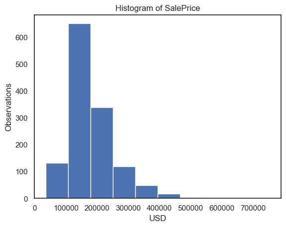

```python
plt.hist(target)
plt.title('Histogram of SalePrice')
plt.xlabel('USD')
plt.ylabel('Observations')
plt.show()
```

The sale prices of houses are clearly skewed to the right. This is problematic for us because we will be tuning our models using k-folds cross validation, and a skewed dataset may introduce misrepresentative samples to train our model on. To address this, we can once again treat for skewness, this time by taking the `log(SalePrice)`.

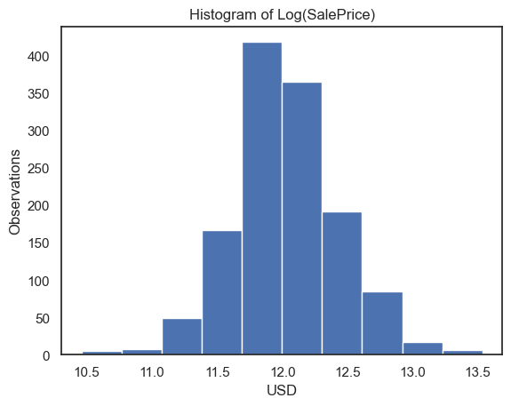

```python
log_target = np.log(target)
plt.hist(log_target)
plt.title('Histogram of Log(SalePrice)')
plt.xlabel('USD')
plt.ylabel('Observations')
plt.show()
```

```python
# repeat for holdout set
log_target_holdout = np.log(target_holdout)
```

This looks better.

Before model fitting, there is one final note to be considered. Traditionally, this may be considered a time-series problem as temporal data have characteristics that impact the choice of models for analysis. Because the goal is *not* specifically about forecasting future data, datetime features will be treated as a categorical feature for simplicity. It is also worth noting that models such as XGBoost would treat datetime features similarly, even in forecasting applications.

```python
from sklearn.model_selection import cross_val_score
from sklearn.model_selection import GridSearchCV
from sklearn.metrics import mean_squared_error


from sklearn.linear_model import LinearRegression
from sklearn.linear_model import ElasticNet
from sklearn.svm import SVR
from sklearn.tree import DecisionTreeRegressor
from sklearn.ensemble import RandomForestRegressor
from xgboost import XGBRegressor

n_folds = 5
```

### 4.1 Linear regression

```python
# Initialize the LinearRegression model
lm = LinearRegression()
cv_scores = cross_val_score(lm, features_scaled, log_target, cv=n_folds, scoring='neg_mean_squared_error')

# Convert scores to positive MSE, then calculate the square root to get RMSE
cv_scores_rmse = np.sqrt(-cv_scores)

# Calculate the average and standard deviation of the RMSE scores
mean_cv_score_rmse = np.mean(cv_scores_rmse)
std_cv_score_rmse = np.std(cv_scores_rmse)

print(f'Average CV Score (Root Mean Squared Error): {mean_cv_score_rmse:,.4f}')
```

```
Average CV Score (Root Mean Squared Error): 80,688,306,173.6390
```

### 4.2 ElasticNet

```python
# Initialize the ElasticNet model
elastic_net_model = ElasticNet(max_iter=10000)

# Define the grid of hyperparameters to search
param_grid = {
    'alpha': [0.1, 0.5, 1.0, 2.0],  # Regularization strength
    'l1_ratio': np.arange(0.0, 1.2, 0.2)  # The ElasticNet mixing parameter, with 0 <= l1_ratio <= 1
}

# Set up the GridSearchCV object with negative mean squared error as the scoring method
grid_search_en = GridSearchCV(estimator=elastic_net_model, param_grid=param_grid, cv=n_folds,
                              scoring='neg_mean_squared_error', verbose=1, n_jobs=-1)

# Fit the GridSearchCV object to the scaled features and log-target
grid_search_en.fit(features_scaled, log_target)

# Get the best parameters and negative MSE score
best_params_en = grid_search_en.best_params_
best_score_en = -grid_search_en.best_score_  # Convert to positive MSE

# Convert the best MSE score to RMSE
best_score_rmse_en = np.sqrt(best_score_en)

print(f'Best parameters found for Elastic Net: {best_params_en}')
print(f'Best CV Score (Root Mean Squared Error for Elastic Net with GridSearch): {best_score_rmse_en:,.4f}')

# The best estimator can be used for predictions or further analysis
best_en_model = grid_search_en.best_estimator_
```

```
Fitting 5 folds for each of 24 candidates, totalling 120 fits
```

[output not shown]

[output cut: 14 more lines]

```
Best parameters found for Elastic Net: {'alpha': 0.1, 'l1_ratio': 0.0}
Best CV Score (Root Mean Squared Error for Elastic Net with GridSearch): 0.1467
```

### 4.3 SVM

```python
svm_model = SVR()
param_grid = {
    'C': [0.1, 1.0, 10.0, 25.0],  # Regularization parameter
    'epsilon': [0.01, 0.1, 0.5],  # Epsilon in the epsilon-SVR model
    'kernel': ['poly', 'rbf', 'sigmoid']  # Specifies the kernel type to be used in the algorithm
}

# Set up the GridSearchCV object
grid_search_svm = GridSearchCV(estimator=svm_model, param_grid=param_grid, cv=n_folds,
                               scoring='neg_mean_squared_error', verbose=1, n_jobs=-1)
grid_search_svm.fit(features_scaled, log_target)

# Get the best parameters and scores
best_params_svm = grid_search_svm.best_params_
best_score_svm = -grid_search_svm.best_score_

# Convert the best MSE score to RMSE
best_score_rmse_svm = np.sqrt(best_score_svm)

print(f'Best parameters found for SVM: {best_params_svm}')
print(f'Best CV Score (Root Mean Squared Error for SVM with GridSearch): {best_score_rmse_svm:,.4f}')

# The best estimator can be used for predictions or further analysis
best_svm_model = grid_search_svm.best_estimator_
```

```
Fitting 5 folds for each of 36 candidates, totalling 180 fits
Best parameters found for SVM: {'C': 1.0, 'epsilon': 0.01, 'kernel': 'rbf'}
Best CV Score (Root Mean Squared Error for SVM with GridSearch): 0.1412
```

### 4.4 Decision Tree

```python
# Initialize the DecisionTreeRegressor model
decision_tree_model = DecisionTreeRegressor()

# Define the grid of hyperparameters to search
param_grid = {
    'max_depth': [5, 10, 20, 30],
    'min_samples_split': [2, 5, 10],
    'min_samples_leaf': [1, 2, 4],
    'max_features': ['sqrt', 'log2']
}

# Set up the GridSearchCV object
grid_search_dt = GridSearchCV(estimator=decision_tree_model, param_grid=param_grid, cv=n_folds,
                              scoring='neg_mean_squared_error', verbose=1, n_jobs=-1)

# Fit the GridSearchCV object to the data
grid_search_dt.fit(features_scaled, log_target)

# Get the best parameters and scores
best_params_dt = grid_search_dt.best_params_
best_score_dt = -grid_search_dt.best_score_

# Convert the best MSE score to RMSE
best_score_rmse_dt = np.sqrt(best_score_dt)

print(f'Best parameters found for Regression Tree: {best_params_dt}')
print(f'Best CV Score (Root Mean Squared Error for Regression Tree with GridSearch): {best_score_rmse_dt:,.4f}')

# The best estimator can be used for predictions or further analysis
best_dt_model = grid_search_dt.best_estimator_
```

```
Fitting 5 folds for each of 72 candidates, totalling 360 fits
Best parameters found for Regression Tree: {'max_depth': 20, 'max_features': 'sqrt', 'min_samples_leaf': 4, 'min_samples_split': 10}
Best CV Score (Root Mean Squared Error for Regression Tree with GridSearch): 0.2311
```

### 4.5 Random Forest

```python
# Initialize the RandomForestRegressor model
random_forest_model = RandomForestRegressor(random_state=42)

# Define the grid of hyperparameters to search
param_grid = {
    'n_estimators': [50, 100, 200],  # Number of trees
    'max_depth': [10, 20, 30],  # Maximum depth of trees
    'min_samples_split': [2, 5, 10],  # Minimum number of samples required to split an internal node
    'min_samples_leaf': [1, 2, 4]  # Minimum number of samples required to be at a leaf node
}

# Set up the GridSearchCV object
grid_search_rf = GridSearchCV(estimator=random_forest_model, param_grid=param_grid, cv=n_folds,
                              scoring='neg_mean_squared_error', verbose=1, n_jobs=-1)

# Fit the GridSearchCV object to the data
grid_search_rf.fit(features_scaled, log_target)

# Get the best parameters and scores
best_params_rf = grid_search_rf.best_params_
best_score_rf = -grid_search_rf.best_score_

# Convert the best MSE score to RMSE
best_score_rmse_rf = np.sqrt(best_score_rf)

print(f'Best parameters found for Random Forest: {best_params_rf}')
print(f'Best CV Score (Root Mean Squared Error for Random Forest with GridSearch): {best_score_rmse_rf:,.4f}')

# The best estimator can be used for predictions or further analysis
best_rf_model = grid_search_rf.best_estimator_
```

```
Fitting 5 folds for each of 81 candidates, totalling 405 fits
Best parameters found for Random Forest: {'max_depth': 30, 'min_samples_leaf': 1, 'min_samples_split': 5, 'n_estimators': 200}
Best CV Score (Root Mean Squared Error for Random Forest with GridSearch): 0.1544
```

### 4.6 XGBoost

```python
# Initialize the XGBRegressor model
xgb_model = XGBRegressor(random_state=42)

# Define the grid of hyperparameters to search
param_grid = {
    'n_estimators': [50, 100, 200],
    'max_depth': [3, 5, 7],
    'learning_rate': [0.01, 0.1, 0.2]
}

# Set up the GridSearchCV object with negative mean squared error as the scoring method
grid_search_xgb = GridSearchCV(estimator=xgb_model, param_grid=param_grid, cv=n_folds,
                               scoring='neg_mean_squared_error', verbose=1, n_jobs=-1)

# Fit the GridSearchCV object to the data
grid_search_xgb.fit(features_scaled, log_target)

# Get the best parameters and negative MSE score
best_params_xgb = grid_search_xgb.best_params_
best_score_xgb = -grid_search_xgb.best_score_  # Convert to positive MSE

# Convert the best MSE score to RMSE
best_score_rmse_xgb = np.sqrt(best_score_xgb)

print(f'Best parameters found for XGBoost: {best_params_xgb}')
print(f'Best CV Score (Root Mean Squared Error for XGBoost with GridSearch): {best_score_rmse_xgb:,.4f}')

# The best estimator can be used for predictions or further analysis
best_xgb_model = grid_search_xgb.best_estimator_
```

```
Fitting 5 folds for each of 27 candidates, totalling 135 fits
Best parameters found for XGBoost: {'learning_rate': 0.2, 'max_depth': 3, 'n_estimators': 200}
Best CV Score (Root Mean Squared Error for XGBoost with GridSearch): 0.1404
```

# 5. Model Evaluation and Selection

```python
scores = {
    'Model': ['ElasticNet', 'SVM', 'Decision Tree', 'Random Forest', 'XGBoost'],
    'Mean 5-fold CV Score (RMSE)': [    # Mean 5-fold CV Score (RMSE) after GridSearch
        best_score_rmse_en,
        best_score_rmse_svm,
        best_score_rmse_dt,
        best_score_rmse_rf,
        best_score_rmse_xgb
    ]}

# Convert the dictionary into a DataFrame
scores_df = pd.DataFrame(scores)
scores_df.sort_values(by='Mean 5-fold CV Score (RMSE)', ascending= True, inplace=True)
pd.options.display.float_format = '{:,.5f}'.format

# Display the DataFrame
scores_df
```

|  | Model | Mean 5-fold CV Score (RMSE) |
| --- | --- | --- |
| 4 | XGBoost | 0.14038 |
| 1 | SVM | 0.14118 |
| 0 | ElasticNet | 0.14670 |
| 3 | Random Forest | 0.15444 |
| 2 | Decision Tree | 0.23115 |

```python
# Make predictions
preds_en = best_en_model.predict(features_scaled_holdout)
preds_svm = best_svm_model.predict(features_scaled_holdout)
preds_dt = best_dt_model.predict(features_scaled_holdout)
preds_rf = best_rf_model.predict(features_scaled_holdout)
preds_xgb = best_xgb_model.predict(features_scaled_holdout)

# Calculate RMSE
rmse_en = np.sqrt(mean_squared_error(log_target_holdout, preds_en))
rmse_svm = np.sqrt(mean_squared_error(log_target_holdout, preds_svm))
rmse_dt = np.sqrt(mean_squared_error(log_target_holdout, preds_dt))
rmse_rf = np.sqrt(mean_squared_error(log_target_holdout, preds_rf))
rmse_xgb = np.sqrt(mean_squared_error(log_target_holdout, preds_xgb))

rmse_values = [
    rmse_en,
    rmse_svm,
    rmse_dt,
    rmse_rf,
    rmse_xgb
]

scores_df['RMSE on Holdout'] = rmse_values
scores_df['RMSE change on Holdout (More Positive is Better)'] =  scores_df['Mean 5-fold CV Score (RMSE)'] - scores_df['RMSE on Holdout']

scores_df
```

|  | Model | Mean 5-fold CV Score (RMSE) | RMSE on Holdout | RMSE change on Holdout (More Positive is Better) |
| --- | --- | --- | --- | --- |
| 4 | XGBoost | 0.14038 | 0.13984 | 0.00053 |
| 1 | SVM | 0.14118 | 0.15251 | -0.01133 |
| 0 | ElasticNet | 0.14670 | 0.27650 | -0.12980 |
| 3 | Random Forest | 0.15444 | 0.14878 | 0.00565 |
| 2 | Decision Tree | 0.23115 | 0.15484 | 0.07630 |

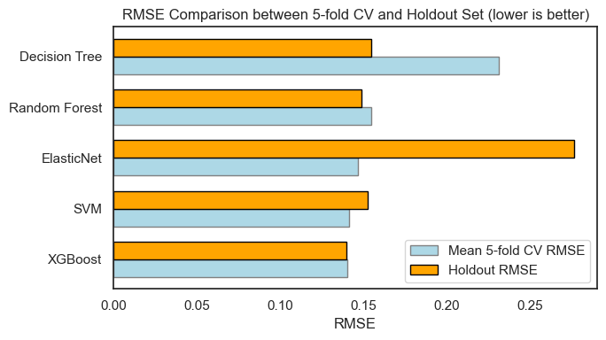

```python
# Set the size of the figure
plt.figure(figsize=(7, 4))

# Plot RMSE from 5-fold CV
cv_rmse = scores_df['Mean 5-fold CV Score (RMSE)']
holdout_rmse = scores_df['RMSE on Holdout']
labels = scores_df['Model']

# Define the Y location for the groups
y = np.arange(len(labels))

# Define the width of the bars
height = 0.35

# Plot the bars horizontally
plt.barh(y - height/2, cv_rmse, height, label='Mean 5-fold CV RMSE', color='lightblue', edgecolor='grey')
plt.barh(y + height/2, holdout_rmse, height, label='Holdout RMSE', color='orange', edgecolor='black')

# Add some text for labels, title and custom y-axis tick labels, etc.
plt.xlabel('RMSE')
plt.title('RMSE Comparison between 5-fold CV and Holdout Set (lower is better)')
plt.yticks(y, labels)
plt.legend()

# Show the plot
plt.tight_layout()
plt.show()
```

# 6. Results interpretation

While it was evident that there were better performing models for this prediction task, it should be noted that the original linear regression model in section 4.1 was not even considered in the overall model selection. It is possible that this could have been improved by passing in variables from Principal Component Analaysis (PCA) or Partial Least Squares (PLS) to improve its performance, but these were ultimately not considered in the interest of maintaining some interpretability.

# 7. Conclusion

The range of tools available to make predictions are richer and more versatile than ever. It is up to the user to masterfully temper and apply these tools appropriately. In this project alone, several pitfalls to predictive analysis were already revealed:

- At the very beginning of the notebook, it was necessary to omit the 'SaleCondition' column because this is information that would only be available concurrent to the target variable being predicted. To include this in the model would allow it to "see into the future", given our research goal of predicting a reasonable selling price for a house.
- There is no blanket approach to imputing missing values in the dataset. In this sample, it was necessary to coalesce some variables to zero, while for another variable, getting the median was deemed more appropriate.
- Not all numerical variables should be treated equally. Part of our feature engineering involved decisions to treat continuous variables as binary and categorical.
- Datetime variables can be tricky to handle, but depending on the model and research question, assumptions can be made to simplify this complexity.
- Feature engineering can sometimes require a mix of domain knowledge an computational knowledge. Due to the nature of datetime variables, it was clearly not appropriate to apply standard scaling.
- For production and execution, it would be beneficial to incorporate Python's object-oriented programing. This would result in cleaner, more readable code, especially when handling the pre-processing and transformations of the holdout dataset.
- As much as possible, it is important to retain some portion of the dataset as the holdout and final test. It was evident that even powerful models need to be fine-tuned so as not to overfit on training data.
- Even with such strong predictive tools, the limitation persists that these models are not able to provide meaningful estimates of the $\beta$'s of how a change in one feature may affect the sale price of a house.